# Prediction Assignment Writeup

Zaw Chit

11/2/2020

## Background

Using devices such as Jawbone Up, Nike FuelBand, and Fitbit it is now possible to collect a large amount of data about personal activity relatively inexpensively. These type of devices are part of the quantified self movement – a group of enthusiasts who take measurements about themselves regularly to improve their health, to find patterns in their behavior, or because they are tech geeks. One thing that people regularly do is quantify how much of a particular activity they do, but they rarely quantify how well they do it. In this project, your goal will be to use data from accelerometers on the belt, forearm, arm, and dumbell of 6 participants. They were asked to perform barbell lifts correctly and incorrectly in 5 different ways. More information is available from the website here: http://web.archive.org/web/20161224072740/http:/groupware.les.inf.puc-rio.br/har (see the section on the Weight Lifting Exercise Dataset)

## Training & Test Data Set

The training data for this project are available here:

https://d396qusza40orc.cloudfront.net/predmachlearn/pml-training.csv

The test data are available here:

https://d396qusza40orc.cloudfront.net/predmachlearn/pml-testing.csv

# Analysis

```r
#load libraries
library(caret)
library(knitr)
library(randomForest)
```

```r
library(rpart)
library(rpart.plot)
#Loading data:

set.seed(12463)
urltrain <-"https://d396qusza40orc.cloudfront.net/predmachlearn/pml-training.csv"
urltest <- "https://d396qusza40orc.cloudfront.net/predmachlearn/pml-testing.csv"

training <- read.csv(url(urltrain), stringsAsFactors=FALSE)
testingset <- read.csv(url(urltest), stringsAsFactors=FALSE)

#Several columns of the raw data have no values.So,these columns and some columns which are not related to predict outcome  will be removed first.
training$classe <- as.factor(training$classe)
training <- training[,-nearZeroVar(training)]
training <- training[,-c(1,2,3,4,5,6,7)]
```

```r
#Cross validation will be performed by splitting the training dataset into:

#1) The models for prediction will be built on training data set which is 70% of the observations.

#2)The accuracy of the prediction models will be evaluated on testing data which is 30% of the observations.

inTrain <- createDataPartition(y=training$classe, p=0.7, list=FALSE)
training <- training[inTrain,]
testing <- training[-inTrain,]
#Imputing NA value using KNN impute method
preObj <- preProcess(training[,-length(training)],method=c("center", "scale", "knnImpute", "pca"), thresh=0.9)
clean_data <- predict(preObj,training[,-length(training)])
```

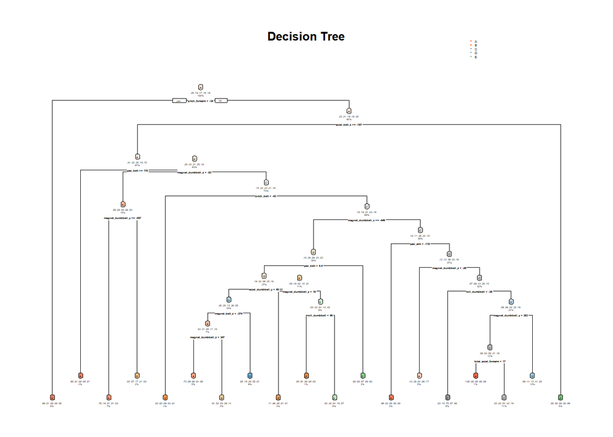

```r
## Prediction 1 Decision Tree
decisionTreeModel <- rpart(classe ~ ., data = training, method = "class")
decisionTreePrediction <- predict(decisionTreeModel, testing, type = "class")

# Plot Decision Tree
rpart.plot(decisionTreeModel, main = "Decision Tree", under = T, faclen = 0)
```

```r
# Using confusion matrix to test results
confusionMatrix(decisionTreePrediction,testing$classe)
```

```
## Confusion Matrix and Statistics
##
##           Reference
## Prediction    A    B    C    D    E
##          A 1065  142   19   37   53
##          B   27  398   43   58   29
##          C   17   60  517  119   96
##          D   76  119  134  416  108
##          E    7   59   21   33  461
##
## Overall Statistics
##
##                Accuracy : 0.6945
##                  95% CI : (0.6801, 0.7085)
##     No Information Rate : 0.2897
##     P-Value [Acc > NIR] : < 2.2e-16
##
##                   Kappa : 0.6121
##
##  Mcnemar's Test P-Value : < 2.2e-16
##
## Statistics by Class:
##
##                      Class: A Class: B Class: C Class: D Class: E
## Sensitivity            0.8935  0.51157   0.7044   0.6275   0.6171
## Specificity            0.9141  0.95294   0.9136   0.8734   0.9644
## Pos Pred Value         0.8093  0.71712   0.6391   0.4877   0.7935
## Neg Pred Value         0.9546  0.89323   0.9343   0.9243   0.9190
## Prevalence             0.2897  0.18911   0.1784   0.1612   0.1816
## Detection Rate         0.2589  0.09674   0.1257   0.1011   0.1121
## Detection Prevalence   0.3199  0.13491   0.1966   0.2073   0.1412
## Balanced Accuracy      0.9038  0.73225   0.8090   0.7504   0.7907
```

```r
# Prediction 2 Random Forest
randomForestModel <- randomForest(training$classe ~., data = clean_data, method = "class")
test <- predict(preObj, testing[,-length(testing)])
confusionMatrix(testing$classe, predict(randomForestModel,test))
```

```
## Confusion Matrix and Statistics
##
##           Reference
## Prediction    A    B    C    D    E
##          A 1192    0    0    0    0
##          B    0  778    0    0    0
##          C    0    0  734    0    0
##          D    0    0    0  663    0
##          E    0    0    0    0  747
##
## Overall Statistics
##
##                Accuracy : 1
##                  95% CI : (0.9991, 1)
##     No Information Rate : 0.2897
##     P-Value [Acc > NIR] : < 2.2e-16
##
##                   Kappa : 1
##
##  Mcnemar's Test P-Value : NA
##
## Statistics by Class:
##
##                      Class: A Class: B Class: C Class: D Class: E
## Sensitivity            1.0000   1.0000   1.0000   1.0000   1.0000
## Specificity            1.0000   1.0000   1.0000   1.0000   1.0000
## Pos Pred Value         1.0000   1.0000   1.0000   1.0000   1.0000
## Neg Pred Value         1.0000   1.0000   1.0000   1.0000   1.0000
## Prevalence             0.2897   0.1891   0.1784   0.1612   0.1816
## Detection Rate         0.2897   0.1891   0.1784   0.1612   0.1816
## Detection Prevalence   0.2897   0.1891   0.1784   0.1612   0.1816
## Balanced Accuracy      1.0000   1.0000   1.0000   1.0000   1.0000
```